# Lab 2: Building a Basic Bar Chart

CMSC471: Introduction to Information Visualization (Fall 2026)

In this lab, you’ll create your first D3.js visualization and learn the basics about D3’s data binding. This is a key concept of D3 — binding data to DOM elements. We will draw a basic bar chart using D3 to help you learn this concept.

Core D3 modules to learn: [D3 scale](https://d3js.org/d3-scale) and [D3 axis](https://d3js.org/d3-axis).

## Quick setup reminder

1. Locate your `CMSC471` folder.
2. Copy your `lab1/` into `lab2/`, and then clean up the content of `script.js`.

   ```
   lab2/
   ├── index.html
   ├── css/
   │   └── styles.css
   └── js/
       └── script.js
   ```

   Then change the lab name in `index.html` to “Lab 2: Building a Basic Bar Chart”.
3. Start a local server:
   - VS Code extension “Live Server”: Click on `Go Live` and it should automatically open a browser for you
   - Python 3: `python -m http.server 8000`; visit: `http://localhost:8000`

## Part 1: Basic bar chart

Open your `script.js` (It should be empty).

### Understanding D3’s select and data binding

Before we start coding, let’s understand two fundamental D3 concepts:

1. **Selection**: D3 uses CSS-style selectors to find elements in your document. When you write `d3.select()` or `d3.selectAll()`, you’re creating a D3 selection object that points to DOM elements.
2. **Data binding**: D3’s power comes from binding data to DOM elements. This creates a mapping between your data and the visual elements representing that data. The binding process uses three key selections:
   - `enter`: For new data points that need elements
   - `update`: For existing data-element pairs
   - `exit`: For elements that no longer have data

   We will try `enter` in this lab. Note that in older version of D3., you must have to explicitly call `enter()` to add new elemtents. In `d3.v7` which is the version we are using, you can use `.join('circle')` instead of `.enter().append('circle')`. We will learn `.join()` in next lab.

### Specify margins

You can start with equal values for all of them. When you arrive at Part 2, you can go back and change these numbers.

```javascript
const margin = {top: 40, right: 40, bottom: 40, left: 60};
const width = 600 - margin.left - margin.right;
const height = 400 - margin.top - margin.bottom;
```

**Why margins?**

1. Prevent clipping of visual elements
2. Make space for axes and labels
3. Ensure visualization is fully visible
4. Follow D3 best practices

**Visual representation**:

```
┌────────────── SVG Container ────────────────┐
│                  ↕ margin.top               │
│         ┌─────── Chart Area ───────┐        │
│    ←→   │                          │   ←→   │
│  margin │                          │ margin │
│   left  │                          │ right  │
│         └──────────────────────────┘        │
│                 ↕ margin.bottom             │
└─────────────────────────────────────────────┘
```

### Setting up the SVG and data

```javascript
// The margin code above

// Sample data
const data = [10, 30, 45, 60, 20]; // you can try
const categories = ['Apple', 'Banana', 'Pear', 'Orange', 'Grape']

// Create SVG
const svg = d3.select('#vis')
    .append('svg')
    .attr('width', width + margin.left + margin.right)
    .attr('height', height + margin.top + margin.bottom)
    .append('g')
    .attr('transform', `translate(${margin.left},${margin.top})`);
```

### Creating scales

D3 scales are functions that map from an input domain (your data) to an output range (pixels on canvas). They’re fundamental to creating visualizations that respond to your data.

**Band scale (for x-axis)**

```javascript
const xScale = d3.scaleBand()
    .domain(categories)
    .range([0, width])
    .padding(0.2)
```

**What’s happening here?**

```
Data index:  0   1   2   3   4
            ┌─┐ ┌─┐ ┌─┐ ┌─┐ ┌─┐
            │ │ │ │ │ │ │ │ │ │  ← Bars
            └─┘ └─┘ └─┘ └─┘ └─┘
              ←→  ←→   Padding
```

**Linear scale (for y-axis)**

```javascript
const yScale = d3.scaleLinear()
    .domain([0, d3.max(data)])
    .range([height, 0]);  // Inverted for SVG coordinates
```

- `scaleLinear()`: Creates a continuous linear mapping
- `domain()`: Sets input range (0 to max data value)
- `range()`: Sets output range (height to 0 pixels)
- Note the inverted range (height to 0, not 0 to height)

**Why invert the y scale?**

- SVG coordinates increase downward (see your Lab 1)
- We want taller bars to go up
- Inverting the scale makes higher values appear higher on screen

### Drawing bars

Now we add bars by binding our data to `rect` SVG objects.

1. **Selection and data binding**

   ```javascript
   svg.selectAll('rect')  // Select all rectangles (none exist yet so they are placeholders)
       .data(data)        // Bind data array to selection
       .enter()           // Get 'enter' selection for new elements
   ```

   **What’s happening?**
   - `selectAll('rect')`: Creates a placeholder selection for rectangles
   - `.data(data)`: Associates our data array with the selection
   - `.enter()`: Creates a new selection for data points that need elements
2. **Creating rectangles**

   ```javascript
   .append('rect')        // Add rectangle for each data point
   .attr('class', 'bar')  // Add CSS class for styling
   ```

3. **Positioning (X and Y)**

   ```javascript
   .attr('x', (d, i) => xScale(categories[i]))  // X position from band scale
   .attr('y', d => yScale(d))       // Y position from linear scale
   ```

   **Understanding the positioning:**
   - `x`: Uses the band scale to position each bar horizontally
   - `y`: Uses the linear scale to set the top of each bar
   - The callback functions (d, i) => … receive:
     - d: The current data value
     - i: The index of the current element
4. **Sizing (width and height)**

   ```javascript
   .attr('width', xScale.bandwidth())        // Width from band scale, a fixed number
   .attr('height', d => height - yScale(d))  // Height calculation
   ```

   **Understanding the sizing:**
   - `width`: Uses band scale’s bandwidth (automatically calculated space for each bar)
   - `height`: Calculates from scaled value to bottom of chart area
   - The height calculation is: total height minus the scaled y-position
5. **Filling in the bars**

   Add the following line `.style('fill', 'steelblue')`

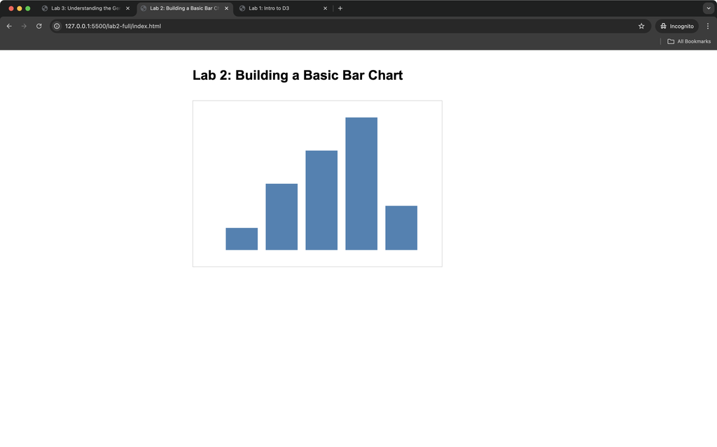

Result of your Part 1

## Part 2: Adding axes

D3 provides four types of axes:

- `d3.axisTop()`: Ticks above the horizontal line
- `d3.axisBottom()`: Ticks below the horizontal line
- `d3.axisLeft()`: Ticks to the left of vertical line
- `d3.axisRight()`: Ticks to the right of vertical line

### Creating a basic axis

```javascript
const xAxis = d3.axisBottom(xScale);
```

**What’s happening:**

```
input scale:  [0, 1, 2, 3, 4]
output:       ┴─────┴─────┴─────┴─────┴
              0     1     2     3     4
```

### Adding x-axis to our SVG

```javascript
svg.append('g')
   .attr('transform', `translate(0,${height})`)
   .call(xAxis);
```

**Before translation:**

```
0     1     2     3     4
┴─────┴─────┴─────┴─────┴
         at y=0
```

**After translation:**

```
┌──────────────────────┐
│                      │
│      Chart Area      │
│                      │
└──────────────────────┘
 0    1    2    3    4
 ┴────┴────┴────┴────┴
     at y=height
```

### Adding y-axis

Repeat for y-axis, but this time it should be on the left side.

```javascript
const yAxis = d3.axisLeft(yScale);

svg.append('g')
    .attr('class', 'y-axis')
    .call(yAxis);
```

### Adding labels

Add x axis label “fruit”

```javascript
svg.append('text')
.attr('class', 'axis-label')
.attr('x', width / 2)
.attr('y', height + margin.bottom - 10)
.style('text-anchor', 'middle')
.text('fruit');
```

Add y axis label “count”

```javascript
svg.append('text')
.attr('class', 'axis-label')
.attr('transform', 'rotate(-90)')
.attr('x', -height / 2)
.attr('y', -margin.left + 15)
.style('text-anchor', 'middle')
.text('count');
```

### Styling axes with CSS

Add these to your `styles.css` (they may not change the appearance very much, depending on your OS and browser).

```javascript
.x-axis path,
.y-axis path,
.x-axis line,
.y-axis line {
    stroke: #333;
    shape-rendering: crispEdges;
}

.x-axis text,
.y-axis text {
    font-size: 12px;
    font-family: Arial, sans-serif;
}

.axis-label {
    font-size: 14px;
    font-weight: bold;
}
```

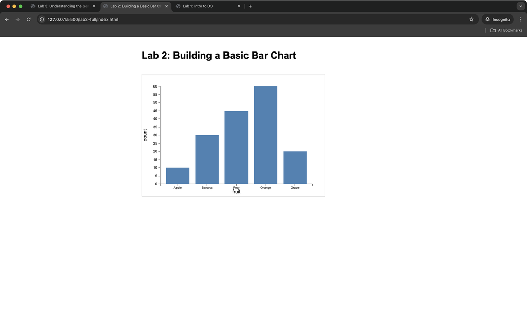

## Part 3: Tweaking your bar chart

Now it’s your time to learn more. Select at least **two** of the following features and implement it (customized ticks, json, grid line, or colors).

### Making customized ticks

The current ticks are automatically generated. To have better control over them (e.g., too dense), read D3.js documentation https://devdocs.io/d3~7/d3-axis#axis_ticks and make it better.

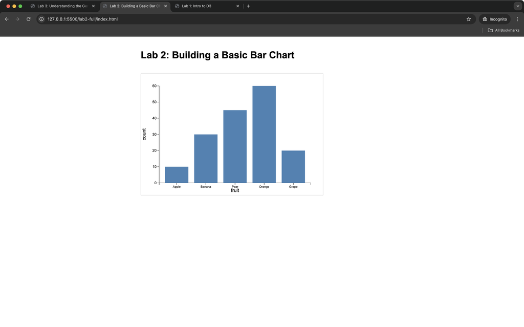

One result of your Part 3

### Feeling comfortable with json?

Instead of

```javascript
const data = [10, 30, 45, 60, 20];
const categories = ['Apple', 'Banana', 'Pear', 'Orange', 'Grape']
```

You can refine the dataset

```javascript
const data = [
    {count: 10, catergory: 'Apple'},
    {count: 30, catergory: 'Banana'},
    {count: 45, catergory: 'Pear'},
    {count: 60, catergory: 'Orange'},
    {count: 20, catergory: 'Grape'}
]
```

Note that you need to change quite a few places (e.g., x-axis, y-axis, and rect) accordingly.

### Playing with colors

You can also play with colors by adding a color variable.

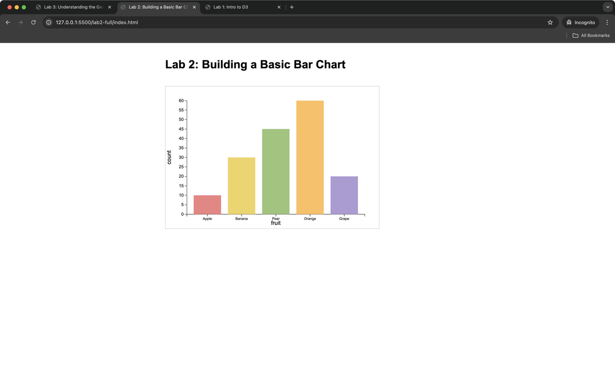

One result of your Part 3

### Adding grid line

There are many ways to add grid lines (e.g., draw lines, extend y-tick). Explore one way to add grid to y-axis.

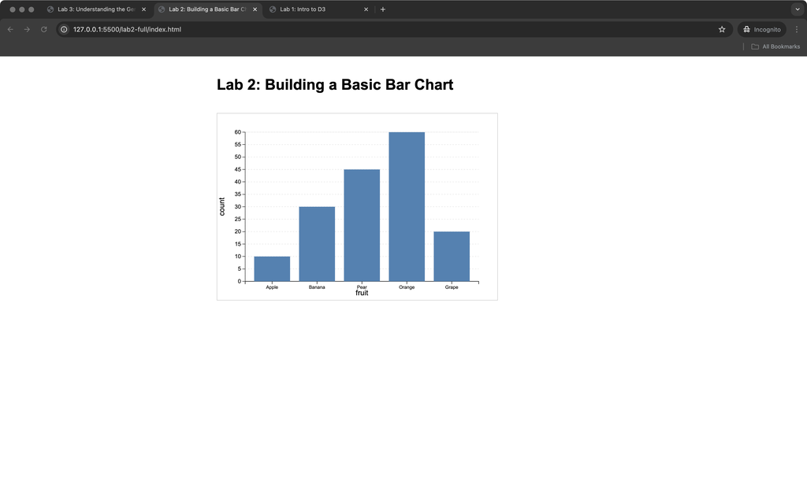

One result of your Part 3

## Checklist ✓

**Basic Implementation**

SVG created with margins  
Scales defined correctly  
Bars rendered  
Axes and labels added

**Styling**

Bars have paddings  
Bars have correct height  
Labels are readable  
At least **two** of the advanced features (ticks, grid line, json, or colors)

### AI usage

- **Permitted uses**: AI tools may be used for brainstorming, generating ideas, improving writing clarity, debugging code, and explaining concepts or code snippets.
- **Prohibited uses for labs**: Using AI tools to directly complete labs is strictly prohibited. If such use is identified, the corresponding lab will receive a 66% score reduction and no further submission for this lab will be accepted.
- **Conceptual understanding checks**: During lab checkouts, we will ask conceptual questions related to the lab to ensure understanding. Repeated inability to answer these questions will result in an additional 33% deduction.

## Common issues and solutions

### Bars not showing

- Check scale domains and ranges
- Verify data binding
- Check SVG dimensions

### Labels misplaced

- Verify x and y calculations
- Check text-anchor setting
- Adjust y offset for readability

### Scale issues

- Confirm data range
- Check scale type
- Verify domain and range values

### Debugging tips

1. **Inspect with developer tools**
   - Use Elements tab to see SVG structure
   - Check if all rectangles are created
   - Verify attribute values
2. **Console logging**

```javascript
   // Log scale outputs
   console.log('xScale(0):', xScale(0));
   console.log('yScale(data[0]):', yScale(data[0]));
```

## Resources

- [D3 Scale Documentation](https://d3js.org/d3-scale)
- [D3 Axis Documentation](https://d3js.org/d3-axis)
- [D3 Selections Guide](https://github.com/d3/d3-selection)
- [SVG Rectangle Reference](https://developer.mozilla.org/en-US/docs/Web/SVG/Element/rect)